# 1. mintegian:Bideo sorten aurkezpena eta txostenaren idaztetAA.

Juan Abasolo

# Bideo sortak

## egitekoak

- Talde bakoitzak bere bideo guztiak elkarrekin izan behar ditu.
- Bideoak izendatuko dira taldearen zenbakiarekin (erromatarrez), giodoia eta zenbakia hurrenkeraren arabera.
  - Lehenengo taldeko lehenengo bideoa: `i-1`
  - Eta laugarreneko seigarrena: `iv-6`
- Ebaluatzaileak bere burua identifikatuko du irakasleak esandako kodearen arabera.

**urriaren 21ekoak**

1. Ekotaldea
2. Txakleta
3. Eman bost
4. Kondoring
5. Energizers

**urriaren 25ekoak**

1. Patxada
2. 3+2
3. TXORIAK
4. Marigorringoak
5. Arimak

## Hasi aurretik,

honetara sartu ebaluatzeko:

[figure not shown]

https://erabili.liberaforms.org/hdib-bideoen-ebaluazioa

## Orain bai: **Bideoak** 📹!

# Txostena

**Edukiaren Sakontasuna eta Analisia**

Edukiak oso sakonak dira eta informazio zehatza eskaintzen dute. Analisi kritikoa oso ona eta sakona da, ideiak argi eta garbi azaltzen dira.

**Argudioen Koherentzia eta Estruktura**

Argudioak oso koherenteak dira eta txostenaren egitura oso ona da. Ideiak modu argi eta ordenatuan aurkezten dira, irakurlea gidatuta.

**Idazkera**

Idazkera oso ona da, akats ortografiko eta gramatikalik gabekoa. Adierazpena oso argia eta ulergarria da, irakurleari ideiak ondo helarazten dizkio.

## Prestatzera!!

## taldeka -1 erabili chatGPT dokumentatu egindako guztia

# Kontuan izatekoak

## ChatGPT : Berbalapiko galanta

1. 2021tik atzera, ok… jakintza ezarrietan
2. Denaren gainean du zer esana, denari buruz jakin ez arren
3. Ez da inor
4. Benetan, ez da inor
5. Euskara ulertzen du, baina egiten ez da hain abila… ezta hain traketsa ere.

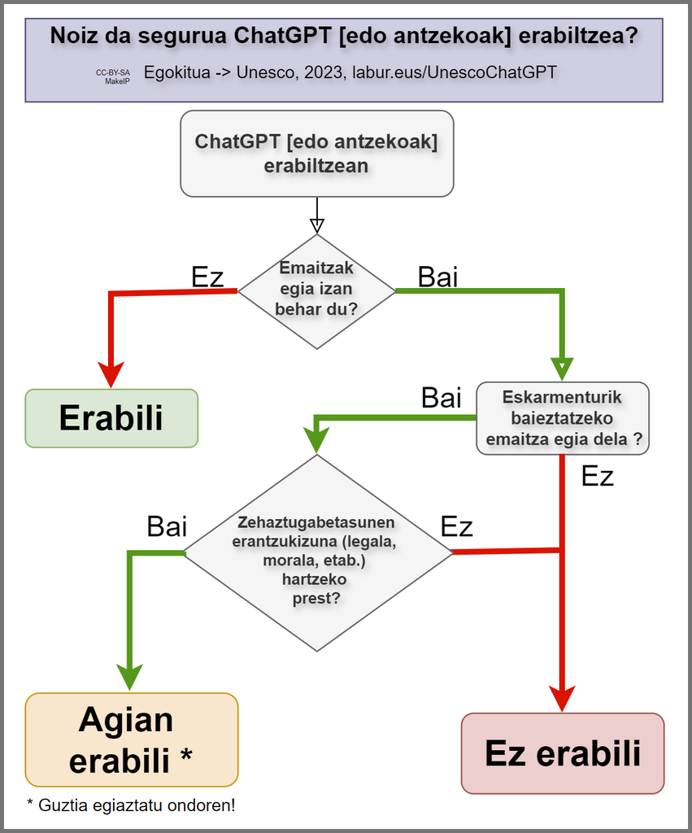

Is it safe to use ChatGPT for your task? Aleksandr Tiulkanov

[+](https://unesdoc.unesco.org/ark:/48223/pf0000385146_spa)

[figure not shown]

[+](https://unesdoc.unesco.org/ark:/48223/pf0000385146_spa)

## Artikuluren bat…

🤪 Alkaissi, H., McFarlane, S. I., Alkaissi, H., & McFarlane, S. I. (2023). Artificial Hallucinations in ChatGPT: Implications in Scientific Writing. *Cureus*, *15*(2). https://doi.org/10.7759/cureus.35179

Carabantes, D., González-Geraldo, J. L., & Jover, G. (2023). ChatGPT could be the reviewer of your next scientific paper. Evidence on the limits of AI-assisted academic reviews. *Profesional de la información*, *32*(5), Article 5. https://doi.org/10.3145/epi.2023.sep.16

Nordling, L. (2023). How ChatGPT is transforming the postdoc experience. *Nature*, *622*(7983), 655–657. https://doi.org/10.1038/d41586-023-03235-8

## Eta zer gehiago?

1. Gehigarriak arakatu
   - YouTube summary [*](https://addons.mozilla.org/eu/firefox/addon/glarity-youtube-summary/)
   - ChatGPT for Google …
2. Jenni, gure laguna da [*](https://www.chatpdf.com/)
3. Beste hamaika… ganoraz aztertzekoak 🙃

# Bestelako teknologiak

## Bilaketez 🔍

`> berba_gakoa site:interesekoa.eus`

… edo

`> filetype:pdf`

`> "berba gakoak"`

`> -kentzeko_berba -site:kentzeko.eremua.da`

Do you know GoogleScholar button?

## APA 7th…

[**Z**](https://zbib.org/)

## Kromo gaitzak

[figure not shown]

[figure not shown]

**Eta gurea zer?**

Zerrendatu eta deskribatu labur GrALera begirako zure premiak

## Bibliografia

Bohannon, J. (2016). Who’s downloading pirated papers? Everyone. *Science*, *352*(6285), 508–512. https://doi.org/10.1126/science.352.6285.508

McKenzie, L. (2017). Sci-Hub’s cache of pirated papers is so big, subscription journals are doomed, data analyst suggests. *Science*. https://doi.org/10.1126/science.aan7164

Nordling, L. (2023). How ChatGPT is transforming the postdoc experience. *Nature*, *622*(7983), 655–657. https://doi.org/10.1038/d41586-023-03235-8

Sabzalieva, E., & Valentini, A. (2023). ChatGPT e inteligencia artificial en la educación superior: Guía de inicio rápido. UNESCO. https://unesdoc.unesco.org/ark:/48223/pf0000385146_spa

Torres-Salinas, D., & Arroyo-Machado, W. (2023). Manual de ChatGPT: Aplicaciones en investigacióny educación universitaria (v1.1.). https://doi.org/10.5281/ZENODO.10025784

**eta estekaren bat**

- UNESCOko Latinoamerika eta Karibean Adimen Artifizialaren gaineko mintegiko gehiago [hemen](https://www.iesalc.unesco.org/2023/04/14/chatgpt-e-inteligencia-artificial-en-la-educacion-superior-guia-de-inicio-rapido/)

Aipamenei formatua emateko:

- https://zbib.org/
- https://www.bibme.org/

Bibliografia multzo handiagoak kodeatzeko

- https://www.zotero.org/

[figure not shown]

Lehenengo mintegia